# Wellons_HW2

Madelynn Wellons

1/12/22

```r
#loading packages
library(tidyverse)
```

```r
library(ggplot2)
```

Chapter 3

1. A variable is observations of the same measurement (e.g. incomes of Sociology PhD graduates at Duke in 2010).

a- Count

b- Categorical

c- Count

d- Continuous

e- Count

f- Count

g- Categorical

h- Qualitative

i- Ordinal

3. B (distribution)

```r
Salaries <- c(85000, 85000, 85000, 85000, 85000, 90000, 90000, 90000, 90000, 100000, 120000, 120000, 125000, 125000, 125000, 130000, 130000)
summary(Salaries)
```

```
##    Min. 1st Qu.  Median    Mean 3rd Qu.    Max.
##   85000   85000   90000  103529  125000  130000
```

a- Average (mean) is $103,529

b- Median is $90,000

c- Min= $85000; max= $130000

d- IQR= 125000-85000 = $40000

5. C (Greek letters)
6. A (log transforming the variable)
7. D, A, C, B

a- The distribution is a semi-normal distribution, peaking around 80 with a bit of a “bump” again around 83 and then having a right skew

b- Yes, the skew is to the right

c- The median would be a better measure due to the skew of the distribution

d- I would use IQR here, since min/max won’t take into account the skew, and SD might not cover the “bump” and the skew as well as the IQR would

9. B (the mean is less than the median)

a- Ordinal

b- Count

c- A bar graph would be the best:

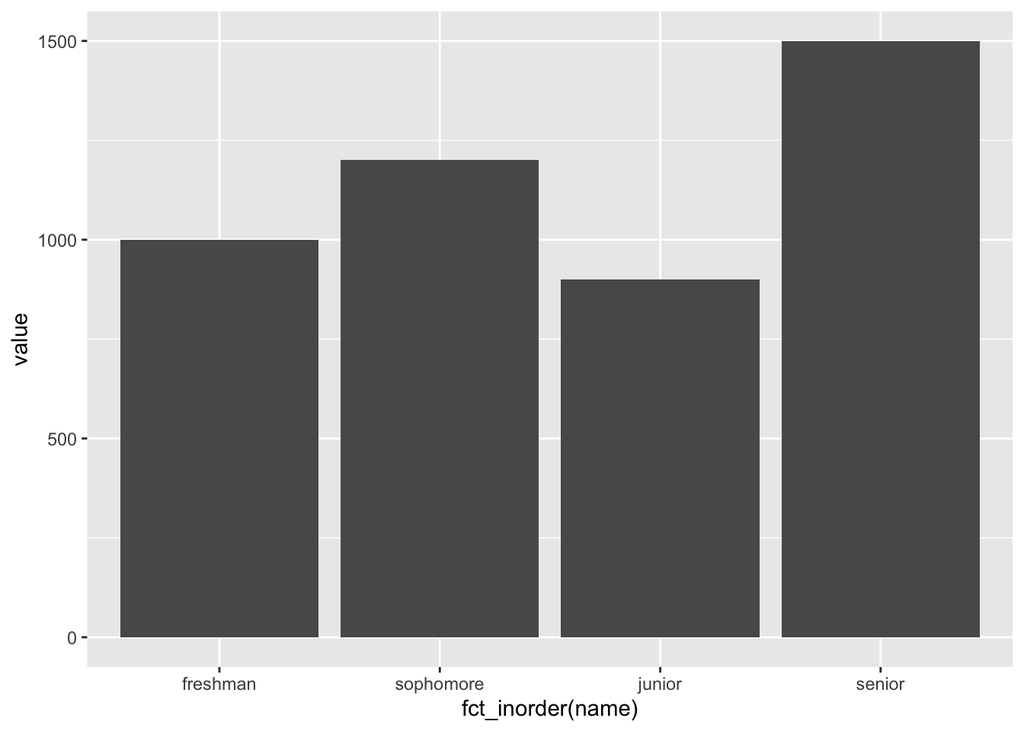

```r
#creating the data frame
StuDist <- data.frame(name=c("freshman", "sophomore", "junior", "senior"), value=c(1000, 1200, 900, 1500))

#plotting the data
ggplot(StuDist, aes(x= fct_inorder(name), y=value)) +
  geom_bar(stat = "identity")
```

a- I collected data from my family on their age:

```r
age <- c(23, 26, 29, 32, 60, 61)
summary(age)
```

```
##    Min. 1st Qu.  Median    Mean 3rd Qu.    Max.
##   23.00   26.75   30.50   38.50   53.00   61.00
```

The distribution has two clusters of data (with me and my 3 sisters on one, and my parents’ ages on another) but is largely just single datapoints (unless plotted as a histogram with large bins, in which case it could be a basic U shaped distribution).

The summary statistics are above, but I will also write them out below:

Range- 23 to 61

Mean= 38.5

Median= 30.5

IQR= 53-26.75 = 26.25

b- The theoretical distribution may have been the ages of people in the US, which is somewhat left-skewed (more old people than young)

c- No I don’t believe it would; there are 2 parents in my family and more than 2 children, so the younger ages are overrepresented.

Chapter 4

1. A conditional distribution is the distribution of a variable given the value of another variable (e.g. the example in class of income given that someone did or did not have a college degree)

a- The conditional mean of depression is lower as income increases

b- No; the graph shows that there may be a relationship between income and depression, but it does not show causation (including the direction of any potential causal relationship)

a-

```r
#base of seniors
288+338
```

```
## [1] 626
```

```r
#probability
288/626
```

```
## [1] 0.4600639
```

The probability of receiving financial aid given that the student is a Senior is 46%

b-

```r
#base of those who receive fin aid
508+349+425+288
```

```
## [1] 1570
```

```r
#prob
288/1570
```

```
## [1] 0.1834395
```

The probability of being a senior given that the student receives financial aid is 18.4%

c-

```r
#base of freshmen
508+371
```

```
## [1] 879
```

```r
#prob
508/879
```

```
## [1] 0.5779295
```

The probability of receiving financial aid given that the student is a freshman is 57.8%

4. Two advantages are that it gives us the conditional mean of Y for any X value, and it can cleanly describe the relationship between Y and X (positive or negative based on the slope, etc.). A disadvantage is that it requires being aware ahead of time what type of line we can use to describe the relationship.

a-

```r
4-(3.5*6)
```

```
## [1] -17
```

The conditional predicted mean of Y when X=6 is -17

b-

```r
4-(3.5*-2)
```

```
## [1] 11
```

The conditional predicted mean of Y when X=-2 is 11.

6. C (covariance)
7. Correlation and covariance are similar concepts, but correlation is rescaled/standardized (to calculate the correlation you can divide the covariance by the SD of X and SD of Y).

a- The shape is linear, a straight line

b- The shape is a curve (a U shape)

c- The curve fits the data better because the residuals would be much lower- the line overlaps with much more of the data than the first example

d- For Figure A, the residuals for the math exam scores of about -2 and 2-3, the data are above the line (and the further they are from 0, the further away from the line they are), while the residuals of -1 to 2 are below the line/curve by about the same amount.

a- Residuals:

```r
5.07-4.72
```

```
## [1] 0.35
```

```r
4.05-4.28
```

```
## [1] -0.23
```

```r
5.33-5.38
```

```
## [1] -0.05
```

```r
4.02-4.22
```

```
## [1] -0.2
```

```r
3.59-3.45
```

```
## [1] 0.14
```

The residuals are .35, -.23, -.05, -.2, and .14

b- OLS uses residuals by finding the line where, when the residuals are squared and summed, that value is as low as possible.

a- One variable that could explain the correlation is income level

b- If Y is graduation rate, X is first gen status, and Z is income level, we could use the following 5 steps (in the textbook as well):

1- Get the mean of Y conditional on Z

2- Subtract out that conditional mean to get the residual of Y (Y^R)

3. Get the mean of X conditional on Z
4. Subtract out that conditional mean to get the residual of X (X^R)
5. Describe the relationship between Y^R and X^R

c- In step 5, all of the influence of Z (the income level) on the relationship has been removed, so you could interpret the residuals remaining as controlled for income level (you would interpret them as normal residuals- the higher means the relationship is not too strong as the points are not close to the line of best fit)